# RED WINE ANALYSIS BY TEAGAN BLACK

### Plot Two

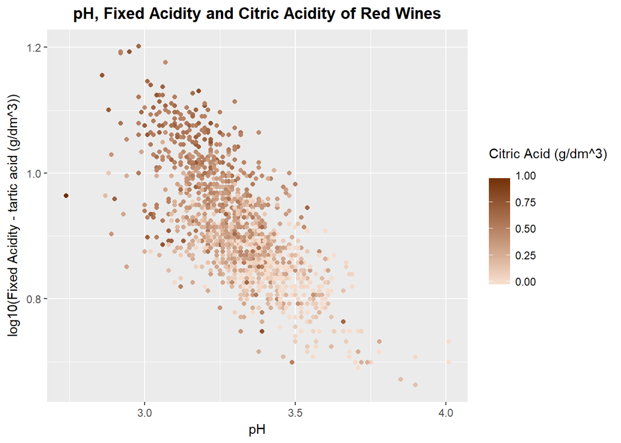

### Description Two

This graph shows a fairly clear relationship between pH and the log of fixed acidity and was the basis for my decision to build a linear model. The color element also shows a relationship with citric acid, which is interesting but that the more tartic acid (fixed acidity), the more citric acidity.

### Plot Three

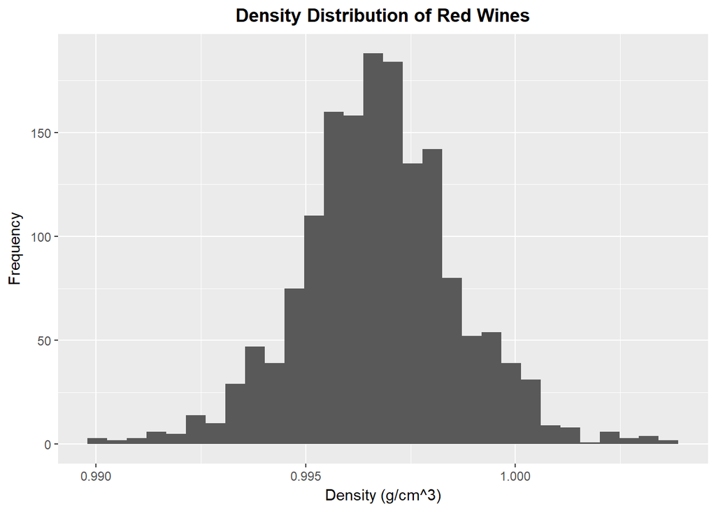

### Description Three

This graphs shows a normal looking distribution of the densities of wine. It is interesting in that it is such a good example of a normal distribution! It is also interesting in that the median density is below that of water (1g/cm^3).

# Reflection

Going through the data analysis of the red wine samples, I expected to focus mostly on factors that affected quality. Once I started diving into the data it became apparent that there was not a wide enough variety in the quality of wines to notice any patterns (or perhaps because of the calculation method for determining the quality a wine received).

However this led to the surprising relationship between fixed volatility and pH, density and citric acid content. It was really interesting to see the graphs evolve from 1-D to 2-D, where you can see a pattern emerging, and finally to add some color to the matter.

I would like to expand the dataset to include wines of different regions, as I think this will allow for a greater range in all the characterisitcs, which might lead to some insightful discoveries. The one thing that would also be interesting to look at, is the relationship between pH and a combination of the acidities recorded.